# final_project_part02_a

I-Ling Yeh

2020/10/26

## Load packages

```r
library(tidyverse)
```

```r
library(dplyr)
library(ggplot2)
library(visdat)
library(corrplot)
```

## Overview

This RMarkdown is machine learning final project part 2. This part of project consists of 3 areas. I will start from using `lm()` and accessing the best model of 4 models. Second, I use `stan_lm()` to train bayesian linear models to fit 2 of the model I fit with `lm()`. Then I set up resampling to tune multiple models.

## Final project data

Reads in the data for the final project.

```r
data_url <- 'https://raw.githubusercontent.com/jyurko/INFSCI_2595_Fall_2020/master/HW/final_project/infsci_2595_final_project_data.csv'

df <- readr::read_csv(data_url, col_names = TRUE)
```

## Model training: Regression models-A

Separate the variables associated with Step 1 in Option B.

```r
step_1_df <- df %>% select(xA, xB, x01:x06, response_1) %>%
  mutate(xA = factor(xA),
         xB = factor(xB))
```

Let’s fit a simple linear model for `response_1`. Use `lm()` to fit linear models with discrete inputs.

```r
lm_01 <- lm(response_1 ~ xA+xB, step_1_df)
```

Summarize the model results with the `summary()` function.

```r
lm_01 %>% summary()
```

```
##
## Call:
## lm(formula = response_1 ~ xA + xB, data = step_1_df)
##
## Residuals:
##      Min       1Q   Median       3Q      Max
## -26.2049  -2.6076  -0.2137   2.7004  26.1931
##
## Coefficients:
##             Estimate Std. Error t value Pr(>|t|)
## (Intercept)   3.3763     0.2426  13.915  < 2e-16 ***
## xAA2          0.3426     0.2051   1.670    0.095 .
## xBB2         -2.4703     0.2826  -8.743  < 2e-16 ***
## xBB3         -7.7089     0.2881 -26.759  < 2e-16 ***
## xBB4         -1.4109     0.3046  -4.632 3.85e-06 ***
## ---
## Signif. codes:  0 '***' 0.001 '**' 0.01 '*' 0.05 '.' 0.1 ' ' 1
##
## Residual standard error: 4.543 on 2008 degrees of freedom
## Multiple R-squared:  0.2954, Adjusted R-squared:  0.294
## F-statistic: 210.5 on 4 and 2008 DF,  p-value: < 2.2e-16
```

Let’s fit a simple linear model for `response_1`. Use `lm()` to fit linear models with continuous inputs.

```r
lm_02 <- lm(response_1 ~ x01+x02+x03+x04+x05+x06, step_1_df)
```

Summarize the model results with the `summary()` function.

```r
lm_02 %>% summary()
```

```
##
## Call:
## lm(formula = response_1 ~ x01 + x02 + x03 + x04 + x05 + x06,
##     data = step_1_df)
##
## Residuals:
##      Min       1Q   Median       3Q      Max
## -25.9007  -2.1221   0.0251   2.2287  22.5315
##
## Coefficients:
##             Estimate Std. Error t value Pr(>|t|)
## (Intercept) 37.14788   32.36197   1.148   0.2512
## x01          1.01973    0.06305  16.174  < 2e-16 ***
## x02         -3.36156    0.22277 -15.090  < 2e-16 ***
## x03          0.15331    0.03640   4.212 2.64e-05 ***
## x04          0.07727    0.03852   2.006   0.0450 *
## x05          0.04013    0.01610   2.493   0.0127 *
## x06          0.32723    0.29464   1.111   0.2669
## ---
## Signif. codes:  0 '***' 0.001 '**' 0.01 '*' 0.05 '.' 0.1 ' ' 1
##
## Residual standard error: 4.842 on 2006 degrees of freedom
## Multiple R-squared:  0.2003, Adjusted R-squared:  0.1979
## F-statistic: 83.75 on 6 and 2006 DF,  p-value: < 2.2e-16
```

Let’s fit a simple linear model for `response_1`. Use `lm()` to fit linear models with all step1 inputs.

```r
lm_03 <- lm(response_1 ~ (.), step_1_df)
```

Summarize the model results with the `summary()` function.

```r
lm_03 %>% summary()
```

```
##
## Call:
## lm(formula = response_1 ~ (.), data = step_1_df)
##
## Residuals:
##      Min       1Q   Median       3Q      Max
## -21.8852  -2.1475  -0.1666   2.0917  19.4622
##
## Coefficients:
##               Estimate Std. Error t value Pr(>|t|)
## (Intercept) 180.491682  27.664490   6.524 8.63e-11 ***
## xAA2          0.432349   0.173763   2.488   0.0129 *
## xBB2         -2.407999   0.253956  -9.482  < 2e-16 ***
## xBB3         -7.868357   0.244465 -32.186  < 2e-16 ***
## xBB4         -1.273069   0.274611  -4.636 3.78e-06 ***
## x01           0.861475   0.050990  16.895  < 2e-16 ***
## x02          -4.136833   0.181353 -22.811  < 2e-16 ***
## x03           0.064684   0.029526   2.191   0.0286 *
## x04           0.037112   0.031071   1.194   0.2324
## x05          -0.003172   0.013071  -0.243   0.8083
## x06          -0.157523   0.239080  -0.659   0.5101
## ---
## Signif. codes:  0 '***' 0.001 '**' 0.01 '*' 0.05 '.' 0.1 ' ' 1
##
## Residual standard error: 3.843 on 2002 degrees of freedom
## Multiple R-squared:  0.4973, Adjusted R-squared:  0.4948
## F-statistic:   198 on 10 and 2002 DF,  p-value: < 2.2e-16
```

Let’s fit a simple linear model for `response_1`. Use `lm()` to fit basis function linear models with all step1 inputs.

```r
lm_04 <- lm(response_1 ~ xA+xB+splines::ns(x01, df = 4)+splines::ns(x02, df = 4)+splines::ns(x03, df = 4)+x04+x05+x06, step_1_df)
```

Summarize the model results with the `summary()` function.

```r
lm_04 %>% summary()
```

```
##
## Call:
## lm(formula = response_1 ~ xA + xB + splines::ns(x01, df = 4) +
##     splines::ns(x02, df = 4) + splines::ns(x03, df = 4) + x04 +
##     x05 + x06, data = step_1_df)
##
## Residuals:
##      Min       1Q   Median       3Q      Max
## -22.8097  -1.9224  -0.0148   1.9057  18.4712
##
## Coefficients:
##                            Estimate Std. Error t value Pr(>|t|)
## (Intercept)                2.529664  22.830068   0.111   0.9118
## xAA2                       0.421810   0.167998   2.511   0.0121 *
## xBB2                      -2.464165   0.245289 -10.046  < 2e-16 ***
## xBB3                      -7.826777   0.236342 -33.116  < 2e-16 ***
## xBB4                      -1.283173   0.265400  -4.835 1.43e-06 ***
## splines::ns(x01, df = 4)1  5.303074   0.971188   5.460 5.34e-08 ***
## splines::ns(x01, df = 4)2  3.420436   0.702766   4.867 1.22e-06 ***
## splines::ns(x01, df = 4)3 16.110024   2.255446   7.143 1.28e-12 ***
## splines::ns(x01, df = 4)4 14.485743   0.877413  16.510  < 2e-16 ***
## splines::ns(x02, df = 4)1 -3.906590   0.846261  -4.616 4.16e-06 ***
## splines::ns(x02, df = 4)2 -7.219413   0.665284 -10.852  < 2e-16 ***
## splines::ns(x02, df = 4)3 -9.555626   1.998848  -4.781 1.88e-06 ***
## splines::ns(x02, df = 4)4 -8.389939   0.987988  -8.492  < 2e-16 ***
## splines::ns(x03, df = 4)1  0.136698   1.199049   0.114   0.9092
## splines::ns(x03, df = 4)2 -0.092215   0.843564  -0.109   0.9130
## splines::ns(x03, df = 4)3  4.137396   2.729516   1.516   0.1297
## splines::ns(x03, df = 4)4  4.789060   1.172546   4.084 4.60e-05 ***
## x04                        0.025767   0.030038   0.858   0.3911
## x05                       -0.003158   0.012623  -0.250   0.8025
## x06                       -0.036679   0.231517  -0.158   0.8741
## ---
## Signif. codes:  0 '***' 0.001 '**' 0.01 '*' 0.05 '.' 0.1 ' ' 1
##
## Residual standard error: 3.708 on 1993 degrees of freedom
## Multiple R-squared:  0.5339, Adjusted R-squared:  0.5295
## F-statistic: 120.2 on 19 and 1993 DF,  p-value: < 2.2e-16
```

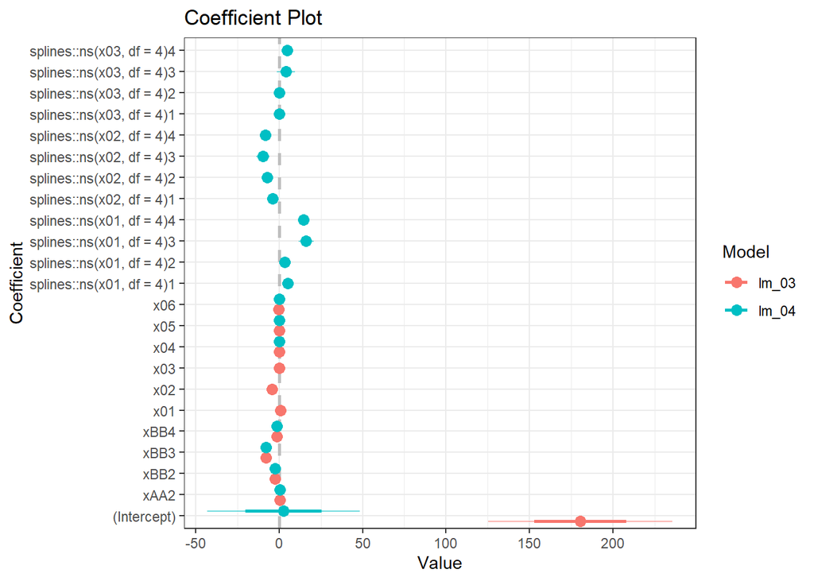

```r
coefplot::multiplot(lm_03, lm_04) + theme_bw()
```

To zoom in, the 4 degrees of `splines::ns(x01)` and `splines::ns(x02)`, the fourth degree of `splines::ns(x03)` are obviously significant coefficients.

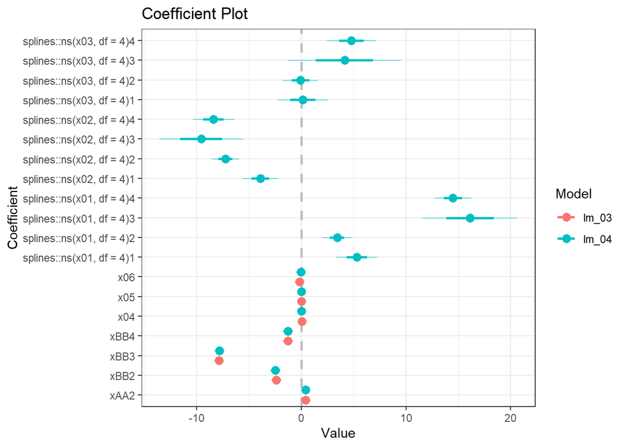

```r
coefplot::multiplot(lm_03, lm_04, coefficients = names(coef(lm_04))[-1]) + theme_bw()
```

Zoom in more, the `xAA2`, `xBB2`, `xBB3`, `xBB4`, `x01`, `x02` are obviously significant coefficients.

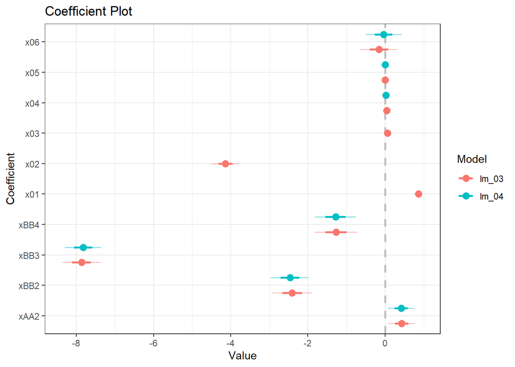

```r
coefplot::multiplot(lm_03, lm_04, coefficients = names(coef(lm_03))[-1]) + theme_bw()
```